# Wskaźnik samobójstw na przestrzeni 1985 - 2015

Autor projektu: Marcin Terlecki, numer indexu: 122943

Data projektu: 2023-02-05

#### **Abstrakt**

Podejmując studia na uczelni ekonomicznej przyświecała mi chęć połączenia wiedzy ze strefy ekonomii oraz mojego pierwotnego wykształcenia czyli świata psychologii. W ramach projektu postanowiłem to wykorzystać i przeprowadzić analizę dotyczącą wskaźnika samobójstw w poszczególnych krajach w okresie 1985 - 2015.

#### **Pytania badawcze**

Główne pytanie to:

- Czy poziom produktu krajowego brutto na mieszkańca wpływa na stopień samobójstw?

W ramach analizy sprawdzam również jak stopień samobójstw rozkłada się w podziale na poszczególne pokolenia, płeć czy badane kraje. W ramach tego powstały dodatkowe pytania:

- W jakiej generacji wskaźnik samobójstw jest najwyższy?
- Czy występują różnice pomiędzy płciami?
- W jakich krajach wskaźnik samobójstw jest najwyższy?
- W jakich krajach wskaźnik samobójstw jest najniższy?

#### **Dane**

Dane wykorzystane w poniższej analizie pochodzą z publicznej witryny kaggle.com. Zbiór danych można pobrać pod zaznaczonym linkiem: [zbiór danych](https://www.kaggle.com/datasets/russellyates88/suicide-rates-overview-1985-to-2016).

Zmienne wykorzystane w analizie:

- **country**: badane kraje,
- **year**: przedział czasowy,
- **sex**: płeć,
- **age**: wiek,
- **suicides_no**: ogólna liczba samobójstw,
- **suicides_100k**: liczba samobójstw na 100 tys. mieszkańców,
- **gdp_per_capita**: produkt krajowy brutto na mieszkańca,
- **generation**: pokolenie.

#### **Analiza eksploracyjna**

W pierwszej części prezentacji przybliżam odpowiedzi dotyczące demografii i geografii problemu samobójstw. Poniższe wykresy dobrze obrazują różnice jakie zachodzą na poszczególnych poziomach.

```r
# Ładowanie potrzebnych bibliotek
library(tidyverse)
library(knitr)
library(forcats)
library(graphics)
library(corrplot)
library(ggpubr)
library(nortest)
library(rstatix)
options(scipen=999)

suicide_rates_overview <- read_csv("Suicide Rates Overview.csv")

suicide_rates_overview <- suicide_rates_overview %>%
  na.omit() %>%
  filter(year < 2016)
```

##### **Wstępny przegląd danych**

```r
glimpse(suicide_rates_overview)
```

```
## Rows: 27,660
## Columns: 10
## $ country        <chr> "Albania", "Albania", "Albania", "Albania", "Albania", …
## $ year           <dbl> 1987, 1987, 1987, 1987, 1987, 1987, 1987, 1987, 1987, 1…
## $ sex            <chr> "male", "male", "female", "male", "male", "female", "fe…
## $ age            <chr> "15-24 years", "35-54 years", "15-24 years", "75+ years…
## $ suicides_no    <dbl> 21, 16, 14, 1, 9, 1, 6, 4, 1, 0, 0, 0, 2, 17, 1, 14, 4,…
## $ population     <dbl> 312900, 308000, 289700, 21800, 274300, 35600, 278800, 2…
## $ suicides_100k  <dbl> 6.71, 5.19, 4.83, 4.59, 3.28, 2.81, 2.15, 1.56, 0.73, 0…
## $ gdp_for_year   <dbl> 2156624900, 2156624900, 2156624900, 2156624900, 2156624…
## $ gdp_per_capita <dbl> 796, 796, 796, 796, 796, 796, 796, 796, 796, 796, 796, …
## $ generation     <chr> "Generation X", "Silent", "Generation X", "G.I. Generat…
```

```r
summary(suicide_rates_overview)
```

```
##    country               year          sex                age
##  Length:27660       Min.   :1985   Length:27660       Length:27660
##  Class :character   1st Qu.:1994   Class :character   Class :character
##  Mode  :character   Median :2002   Mode  :character   Mode  :character
##                     Mean   :2001
##                     3rd Qu.:2008
##                     Max.   :2015
##   suicides_no        population       suicides_100k     gdp_for_year
##  Min.   :    0.0   Min.   :     278   Min.   :  0.00   Min.   :      46919625
##  1st Qu.:    3.0   1st Qu.:   97535   1st Qu.:  0.91   1st Qu.:    8976207713
##  Median :   25.0   Median :  430725   Median :  5.98   Median :   48013606745
##  Mean   :  243.4   Mean   : 1850689   Mean   : 12.81   Mean   :  447100884244
##  3rd Qu.:  132.0   3rd Qu.: 1491041   3rd Qu.: 16.60   3rd Qu.:  260202429150
##  Max.   :22338.0   Max.   :43805214   Max.   :224.97   Max.   :18120714000000
##  gdp_per_capita    generation
##  Min.   :   251   Length:27660
##  1st Qu.:  3436   Class :character
##  Median :  9283   Mode  :character
##  Mean   : 16816
##  3rd Qu.: 24796
##  Max.   :126352
```

[figure not shown]

```r
table1 <- suicide_rates_overview %>%
  select(year, suicides_no) %>%
  na.omit() %>%
  group_by(year) %>%
  summarise('liczba samobojstw' = mean(suicides_no)) %>%
  arrange(desc(year))


plot1 <- ggplot(suicide_rates_overview, aes(x = year, y = suicides_no)) +
  geom_bar(stat = "identity", fill = "#4f5d75") +
  labs(x= "Rok", y = "Średnia ilość samobójstw") +
  scale_x_continuous(breaks = seq(1985, 2015,by = 1)) +

  theme_classic() +
  theme(legend.position = "top",
        plot.title = element_text(hjust = 0, size = 10, color = "#4f5d75"),
        axis.title.y = element_text(margin = margin(r = 10), size = 8),
        axis.title.x = element_text(margin = margin(r = 10), size = 8),
        axis.text.x = element_text(angle = 45, vjust = 1, hjust = 1, size = 8),
        axis.text = element_text(size = 8))

plot1
```

___________________________________________________________________________________________________________

##### **Histogram**

Na poniższych wykresach jest zaprezentowany histogram dla ilosci samobójstw na 100 tys. mieszkańców. Wykres przybiera forme prawoskośną i odbiega od rozkładu normalnego. W ramach testu normalności został użyty test Kolmogorova-Smirnova.

```r
lillie.test(suicide_rates_overview$suicides_100k)
```

```
##
##  Lilliefors (Kolmogorov-Smirnov) normality test
##
## data:  suicide_rates_overview$suicides_100k
## D = 0.24973, p-value < 0.00000000000000022
```

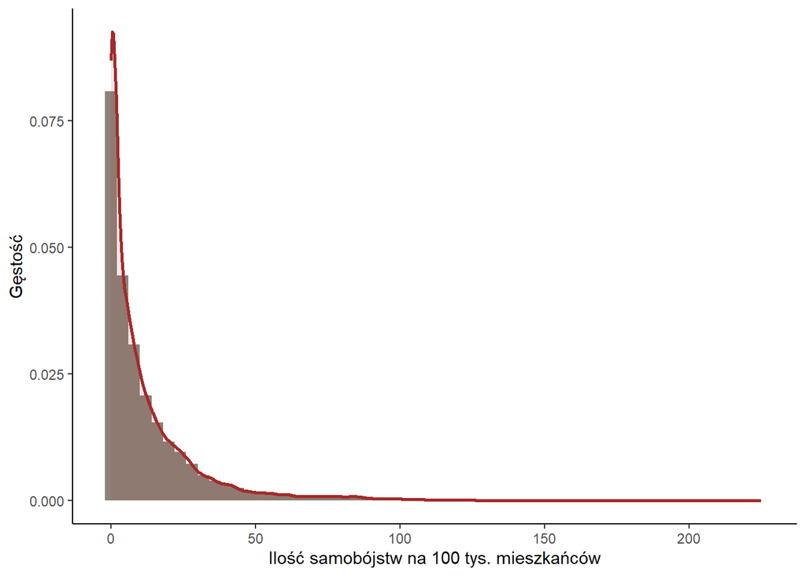

```r
hist1 <- ggplot(suicide_rates_overview) +
  geom_histogram(aes(x = suicides_100k, after_stat(density)), binwidth = 4, fill = "antiquewhite4") +
  labs(
       x = "Ilość samobójstw na 100 tys. mieszkańców",
       y = "Gęstość") +
  geom_density(aes(x = suicides_100k),alpha = 0.1, fill = "brown", color = "brown", lwd = 1) +
  theme_classic()

hist1
```

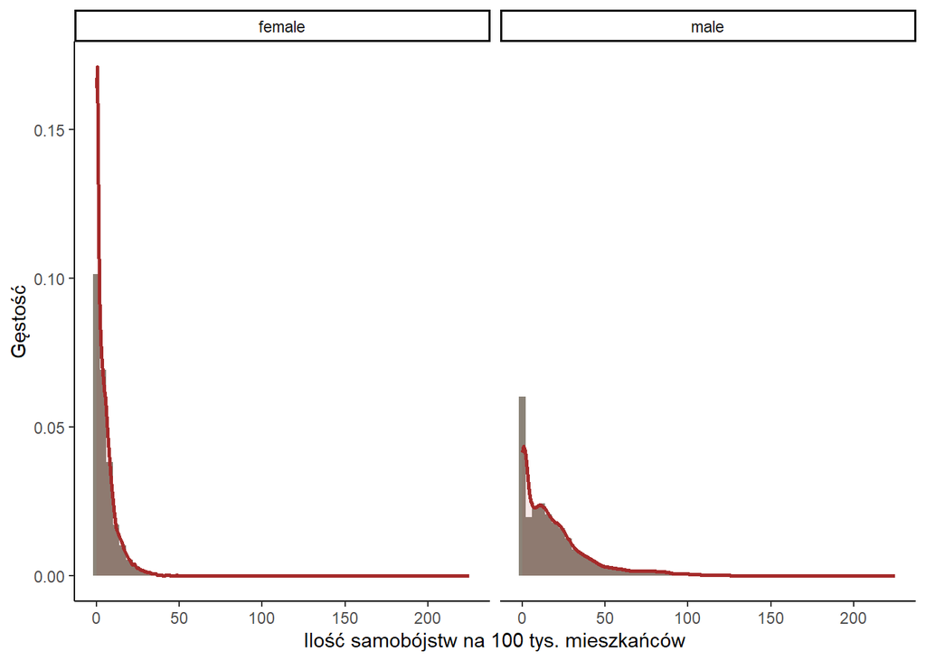

```r
hist2 <- ggplot(suicide_rates_overview) +
  geom_histogram(aes(x = suicides_100k, after_stat(density)), binwidth = 4, fill = "antiquewhite4") +
  labs(
       x = "Ilość samobójstw na 100 tys. mieszkańców",
       y = "Gęstość") +
  geom_density(aes(x = suicides_100k),alpha = 0.1, fill = "brown", color = "brown", lwd = 1) +
  facet_wrap(~sex, ncol = 2) +
  theme_classic()

hist2
```

___________________________________________________________________________________________________________

##### **Średnia liczba samobójstw na 100 tys. mieszkańców w podziale na pokolenie**

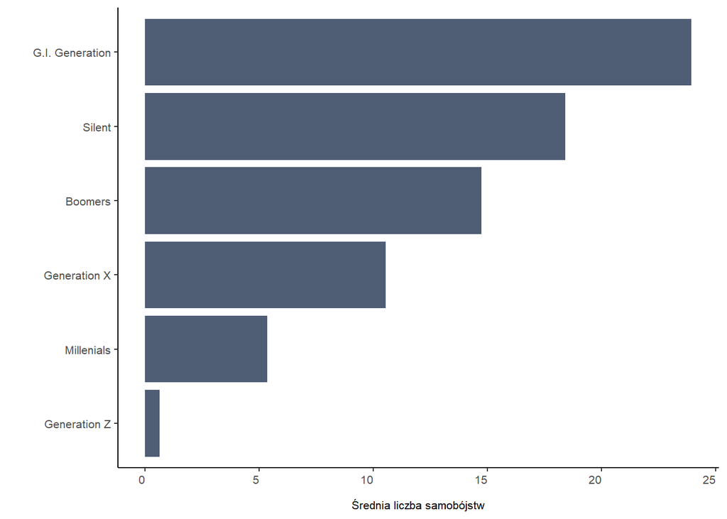

```r
avg_by_gen <- suicide_rates_overview %>%
  select(generation, suicides_100k) %>%
  na.omit() %>%
  group_by(generation) %>%
  summarise(Srednia = mean(suicides_100k))

plot2 <- ggplot(avg_by_gen, aes(y = fct_reorder(generation, Srednia), x = Srednia)) +
  geom_bar(stat = "identity", fill = "#4f5d75") +
  labs(y = "", x = "Średnia liczba samobójstw") +
  theme_classic() +
  theme(legend.position = "top",
        plot.title = element_text(hjust = 0, size = 12, color = "#2d3142"),
        axis.title.x = element_text(margin = margin(t = 10), size = 8,),
        axis.title.y = element_text(margin = margin(r = 10), size = 8),
        axis.text.x = element_text( vjust = 1, hjust = 1, size = 8),
        axis.text = element_text(size = 8))


avg_by_sex <- suicide_rates_overview %>%
  select(generation, year, suicides_100k) %>%
  na.omit() %>%
  group_by(generation, year) %>%
  summarise(Srednia = mean(suicides_100k))

plot3 <- ggplot(avg_by_sex, aes(x = year, y = Srednia, color = generation)) +
  geom_line(size = 1) +
  labs(y = "Średnia liczba samobójstw na 100 tys. mieszkańców", x = "Rok")+
  scale_x_continuous(breaks = seq(1985, 2015,by = 2)) +
  scale_color_discrete(name = "")+
  theme_classic() +
  theme(legend.position = "top",
        plot.title = element_text(hjust = 0, size = 12, color = "#2d3142"),
        axis.title.x = element_text(margin = margin(t = 10), size = 8,),
        axis.title.y = element_text(margin = margin(r = 10), size = 8),
        axis.text.x = element_text( vjust = 1, hjust = 1, size = 8),
        axis.text = element_text(size = 8))


plot2
```

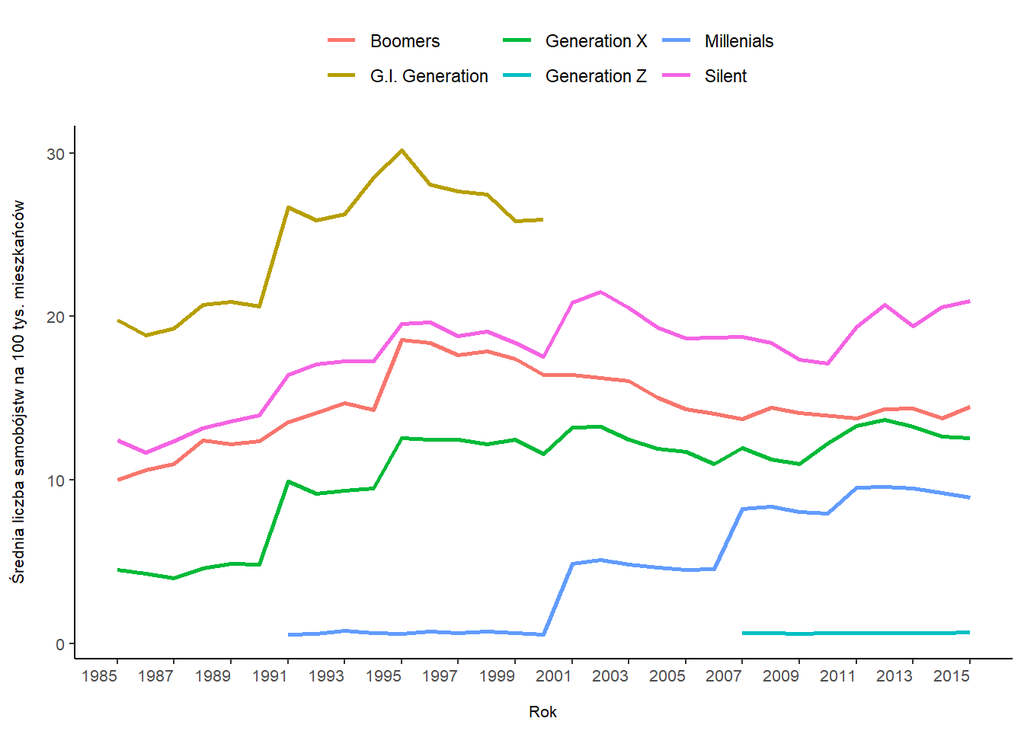

```r
plot3
```

___________________________________________________________________________________________________________

##### **Średnia liczba samobójstw na 100 tys. mieszkańców w podziale na wiek**

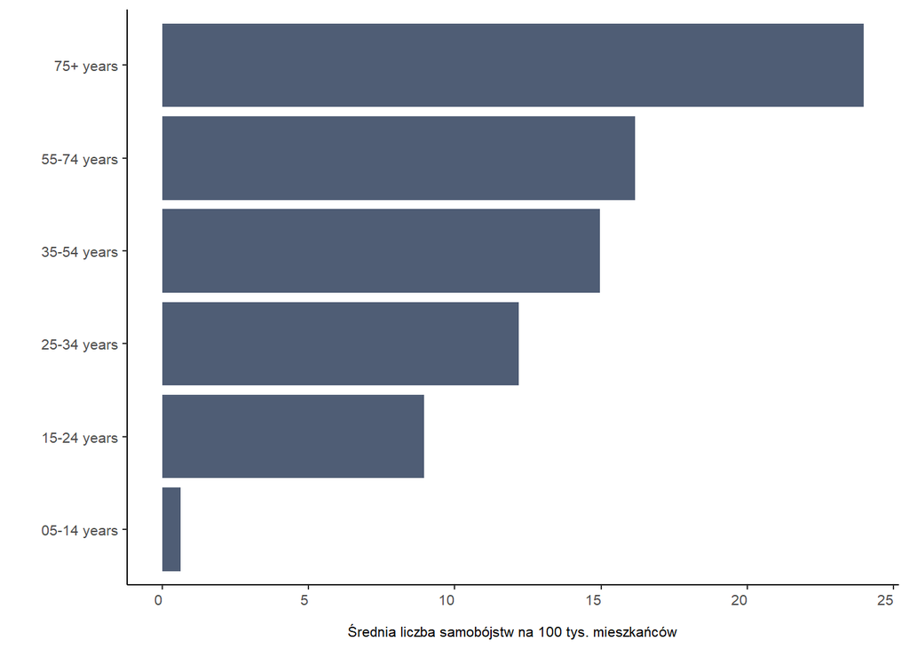

```r
avg_by_age <- suicide_rates_overview %>%
  select(age, suicides_100k) %>%
  na.omit() %>%
  group_by(age) %>%
  summarise(Srednia = mean(suicides_100k))

plot4 <- ggplot(avg_by_age, aes(y = fct_reorder(age, Srednia), x = Srednia)) +
  geom_bar(stat = "identity", fill = "#4f5d75") +
  labs(y = "", x = "Średnia liczba samobójstw na 100 tys. mieszkańców")+
  theme_classic() +
  theme(legend.position = "top",
        plot.title = element_text(hjust = 0, size = 12, color = "#2d3142"),
        axis.title.x = element_text(margin = margin(t = 10), size = 8,),
        axis.title.y = element_text(margin = margin(r = 10), size = 8),
        axis.text.x = element_text( vjust = 1, hjust = 1, size = 8),
        axis.text = element_text(size = 8))

avg_by_sex <- suicide_rates_overview %>%
  select(age, year, suicides_100k) %>%
  na.omit() %>%
  group_by(age, year) %>%
  summarise(Srednia = mean(suicides_100k))

plot5 <- ggplot(avg_by_sex, aes(x = year, y = Srednia, color = age)) +
  geom_line(size = 1) +
  labs(y = "Średnia liczba samobójstw na 100 tys. mieszkańców", x = "Rok")+
  scale_x_continuous(breaks = seq(1985, 2015,by = 2)) +
  scale_color_discrete(name = "")+
  theme_classic() +
  theme(legend.position = "top",
        plot.title = element_text(hjust = 0, size = 12, color = "#2d3142"),
        axis.title.x = element_text(margin = margin(t = 10), size = 8,),
        axis.title.y = element_text(margin = margin(r = 10), size = 8),
        axis.text.x = element_text( vjust = 1, hjust = 1, size = 8),
        axis.text = element_text(size = 8))


plot4
```

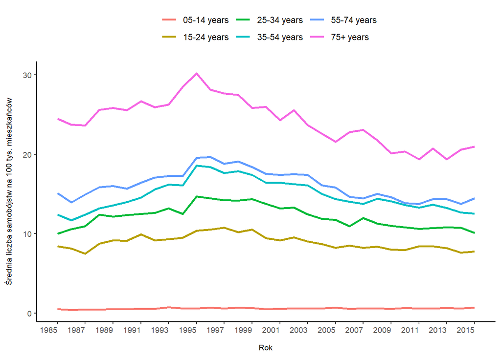

```r
plot5
```

Powyższe wyniki dobrze pokazują różnice międzypokoleniowe i potwierdzają istniejące badania. W literaturze znajdziemy przykłady, które wskazują, że pokolenia z okresu 1930 - 1990 mają wyższy wskaźnik samobójstw. Według niektórych badaczy może się to wiązać z brakiem umiejętności regulowania emocji oraz niechęcią do kontaktu ze specjalistą. ___________________________________________________________________________________________________________

##### **Średnia liczba samobójstw na 100 tys. mieszkańców w podziale na płeć**

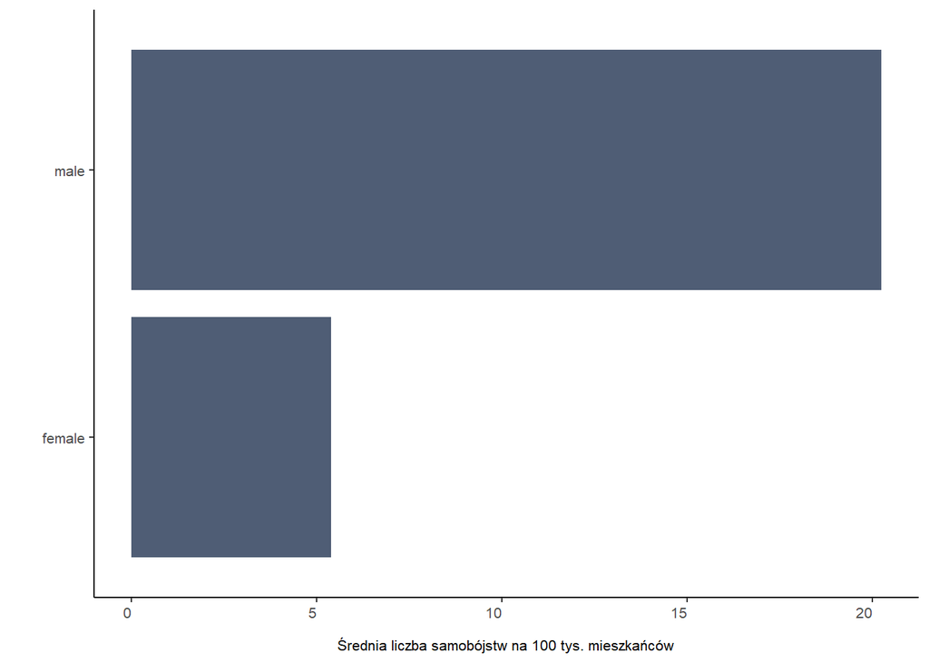

```r
avg_by_sex <- suicide_rates_overview %>%
  select(sex, suicides_100k) %>%
  na.omit() %>%
  group_by(sex) %>%
  summarise(Srednia = mean(suicides_100k))

plot6 <- ggplot(avg_by_sex, aes(y = fct_reorder(sex, Srednia), x = Srednia)) +
  geom_bar(stat = "identity", fill = "#4f5d75") +
  labs(y = "", x = "Średnia liczba samobójstw na 100 tys. mieszkańców")+
  theme_classic() +
  theme(legend.position = "top",
        plot.title = element_text(hjust = 0, size = 12, color = "#2d3142"),
        axis.title.x = element_text(margin = margin(t = 10), size = 8,),
        axis.title.y = element_text(margin = margin(r = 10), size = 8),
        axis.text.x = element_text( vjust = 1, hjust = 1, size = 8),
        axis.text = element_text(size = 8))

plot6
```

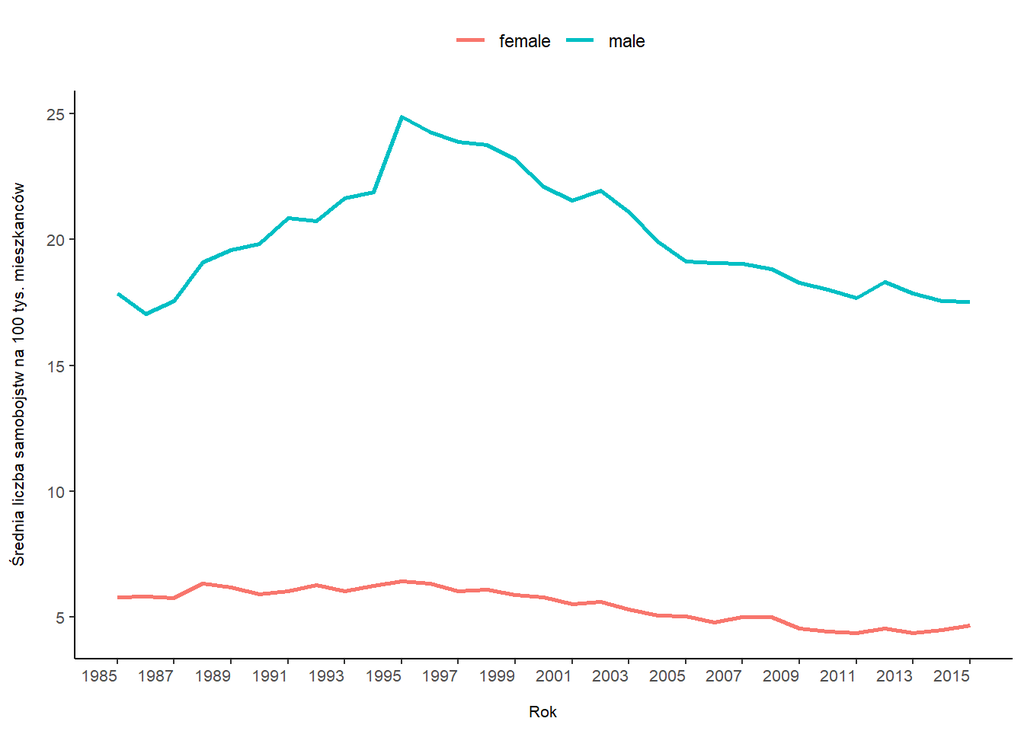

```r
avg_by_sex <- suicide_rates_overview %>%
  select(sex, year, suicides_100k) %>%
  na.omit() %>%
  group_by(sex, year) %>%
  summarise(Srednia = mean(suicides_100k))

plot7 <- ggplot(avg_by_sex, aes(x = year, y = Srednia, color = sex)) +
  geom_line(size = 1) +
  labs(y = "Średnia liczba samobojstw na 100 tys. mieszkanców", x = "Rok")+
  scale_x_continuous(breaks = seq(1985, 2015,by = 2)) +
  scale_color_discrete(name = "")+
  theme_classic() +
  theme(legend.position = "top",
        plot.title = element_text(hjust = 0, size = 12, color = "#2d3142"),
        axis.title.x = element_text(margin = margin(t = 10), size = 8,),
        axis.title.y = element_text(margin = margin(r = 10), size = 8),
        axis.text.x = element_text( vjust = 1, hjust = 1, size = 8),
        axis.text = element_text(size = 8))

plot7
```

Powyższy podział również dobrze oddaje statystyki nie tylko ze świata, ale również z Polski. Mężczyżni częsciej targają się na własne życie i są w tym skuteczni. Natomiast kobiety często podejmują nieudane próby samobójcze. Jednak różnica w proporcjach jest zauważalna gołym okiem. ___________________________________________________________________________________________________________

##### **Kraje z najwyższym wskaźnikiem samobójstw**

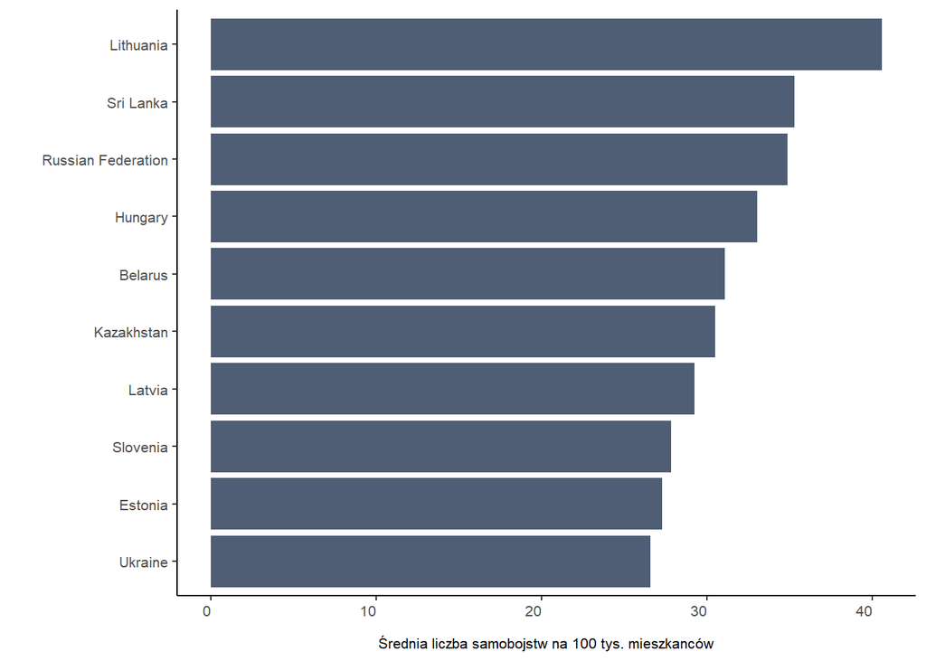

```r
# top 10
#
avg_by_country <- suicide_rates_overview %>%
  select(country, suicides_100k) %>%
  group_by(country) %>%
  summarise(Srednia = mean(suicides_100k)) %>%
  top_n(10, Srednia) %>%
  arrange(desc(Srednia))


plot8 <- ggplot(avg_by_country, aes(y = fct_reorder(country, Srednia), x = Srednia)) +
  geom_bar(stat = "identity", fill = "#4f5d75") +
  labs(y = "", x = "Średnia liczba samobojstw na 100 tys. mieszkanców")+
  theme_classic() +
  theme(legend.position = "top",
        plot.title = element_text(hjust = 0, size = 12, color = "#2d3142"),
        axis.title.x = element_text(margin = margin(t = 10), size = 8,),
        axis.title.y = element_text(margin = margin(r = 10), size = 8),
        axis.text.x = element_text( vjust = 1, hjust = 1, size = 8),
        axis.text = element_text(size = 8))

plot8
```

##### **Kraje z najniższym wskaźnikiem samobójstw**

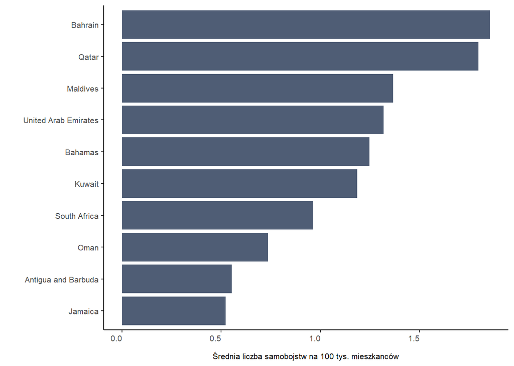

```r
# bottom 10
#
avg_by_country_bottom <- suicide_rates_overview %>%
  select(country, suicides_100k) %>%
  group_by(country) %>%
  summarise(Srednia = mean(suicides_100k)) %>%
  filter(Srednia != 0) %>%
  arrange(desc(Srednia)) %>%
  slice_tail(n = 10)

plot9 <- ggplot(avg_by_country_bottom, aes(y = fct_reorder(country, Srednia), x = Srednia)) +
  geom_bar(stat = "identity", fill = "#4f5d75") +
  labs(y = "", x = "Średnia liczba samobojstw na 100 tys. mieszkanców") +
  theme_classic() +
  theme(legend.position = "top",
        plot.title = element_text(hjust = 0, size = 12, color = "#2d3142"),
        axis.title.x = element_text(margin = margin(t = 10), size = 8),
        axis.title.y = element_text(margin = margin(r = 10), size = 8),
        axis.text.x = element_text( vjust = 1, hjust = 1, size = 8),
        axis.text = element_text(size = 8))

plot9
```

Jak można zauważyć na wykresie pokazującym kraje z najwyższym wskaźnikiem samobójstw, 8 na 10 krajów należało do byłego komunistycznego bloku wschodniego. Nasuwa to wiele pytań i pomysłów na kolejne badania. Biorąc pod uwagę specyfikę społeczną i podobieństwa kulturowe może to być istotny czynnik wpływający na wskaźnik samobójstw.

Gdy spojrzymy na wykres z krajami o najniższym wskaźniku samobójstw można również zauważyć pewną wspólną ceche znajdujących się tam państw. Mianowicie 6 na 10 krajów to kraje o kulturze i religi muzułmańskiej. Jednocześnie kraje z tej listy znajdują się w strefie o wysokiej średniej temperaturze powietrza w ciągu roku, co również może by czynnikiem zmniejszającym wskaźnik samobójstw. ___________________________________________________________________________________________________________

#### **Analiza zaawansowana**

Pierwszy rzut oka na powyższe wykresy przyniósł pewne przypuszczenia dotyczące połączenia sytuacji kulturowej i społecznej danych krajów, a wskaźnikiem samobójstw. Natomiast przy pomocy korelacji i regresji linowej dowiadujemy sie, że wskaźnik nie jest zależny od produktu krajowego brutto na mieszkańca.

**Korelacja pomiędzy produktem krajowym brutto na mieszkańca, a wskaźnikiem samobójstw na 100 tys. mieszkańców**

```r
avg_table <- suicide_rates_overview %>%
  na.omit() %>%
  group_by(country) %>%
  summarise(gdp_per_capita = mean(gdp_per_capita), suicides_100k = mean(suicides_100k),
            suicides_no = mean(suicides_no), gdp_for_year = mean(gdp_for_year)) %>%
  select(gdp_per_capita, suicides_100k, suicides_no, gdp_for_year)

cor.test(avg_table$gdp_per_capita, avg_table$suicides_100k)
```

```
##
##  Pearson's product-moment correlation
##
## data:  avg_table$gdp_per_capita and avg_table$suicides_100k
## t = 0.41423, df = 98, p-value = 0.6796
## alternative hypothesis: true correlation is not equal to 0
## 95 percent confidence interval:
##  -0.1558914  0.2362847
## sample estimates:
##        cor
## 0.04180683
```

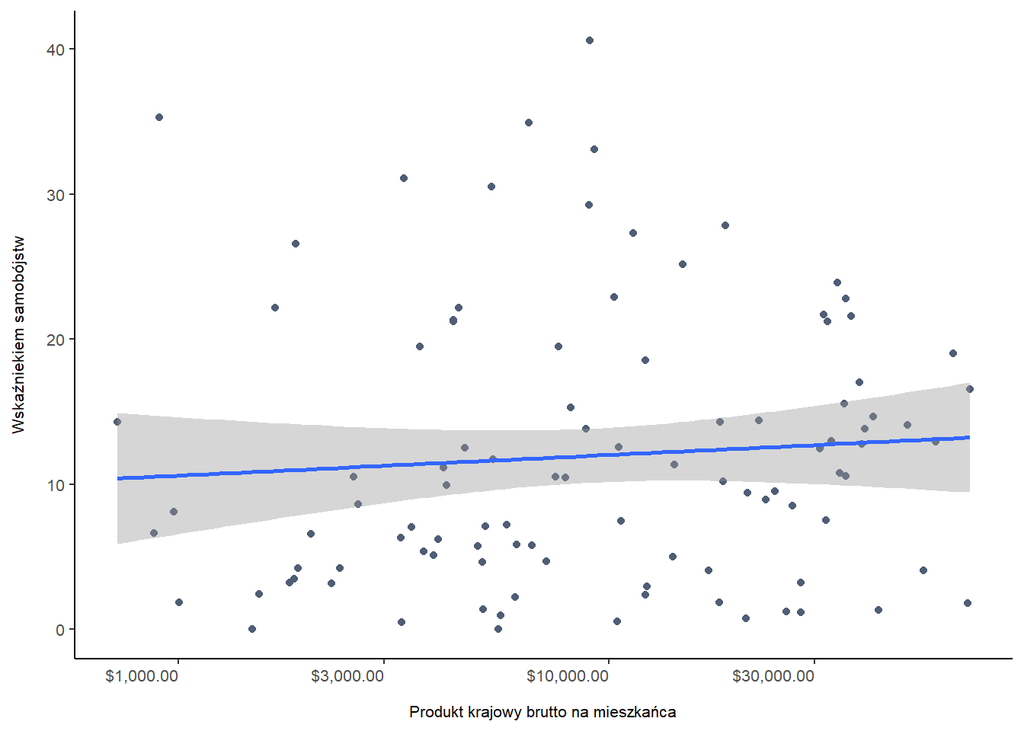

```r
ggplot(avg_table, aes(x = gdp_per_capita, y = suicides_100k)) +
  geom_point(color = "#4f5d75", fill = "#4f5d75") +
  geom_smooth(method = "lm", se = TRUE) +
  xlab("Produkt krajowy brutto na mieszkańca") +
  ylab("Wskaźniekiem samobójstw") +
  theme_classic() +
  theme(legend.position = "top",
        plot.title = element_text(hjust = 0, size = 12, color = "#2d3142"),
        axis.title.x = element_text(margin = margin(t = 10), size = 8),
        axis.title.y = element_text(margin = margin(r = 10), size = 8),
        axis.text.x = element_text( vjust = 1, hjust = 1, size = 8),
        axis.text = element_text(size = 8)) +
  scale_x_log10(labels = scales::dollar_format(suffix = ""))
```

**Regresja liniowa**

```r
avg_table <- suicide_rates_overview %>%
  na.omit() %>%
  group_by(country) %>%
  summarise(gdp_per_capita = mean(gdp_per_capita), suicides_100k = mean(suicides_100k),
            suicides_no = mean(suicides_no), gdp_for_year = mean(gdp_for_year)) %>%
  select(country, gdp_per_capita, suicides_100k, suicides_no, gdp_for_year)

lm <- lm(suicides_100k ~ gdp_per_capita, data = avg_table )
summary(lm)
```

```
##
## Call:
## lm(formula = suicides_100k ~ gdp_per_capita, data = avg_table)
##
## Residuals:
##     Min      1Q  Median      3Q     Max
## -11.718  -7.169  -1.787   4.896  28.782
##
## Coefficients:
##                   Estimate  Std. Error t value           Pr(>|t|)
## (Intercept)    11.58628377  1.31899608   8.784 0.0000000000000524 ***
## gdp_per_capita  0.00002389  0.00005768   0.414               0.68
## ---
## Signif. codes:  0 '***' 0.001 '**' 0.01 '*' 0.05 '.' 0.1 ' ' 1
##
## Residual standard error: 9.413 on 98 degrees of freedom
## Multiple R-squared:  0.001748,   Adjusted R-squared:  -0.008438
## F-statistic: 0.1716 on 1 and 98 DF,  p-value: 0.6796
```

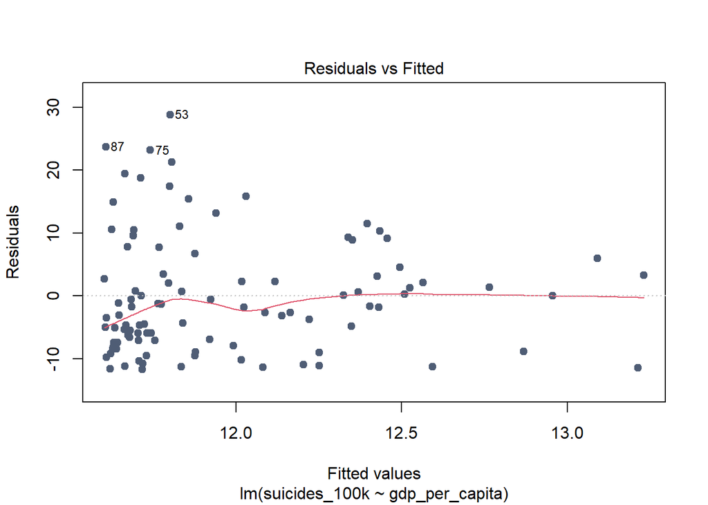

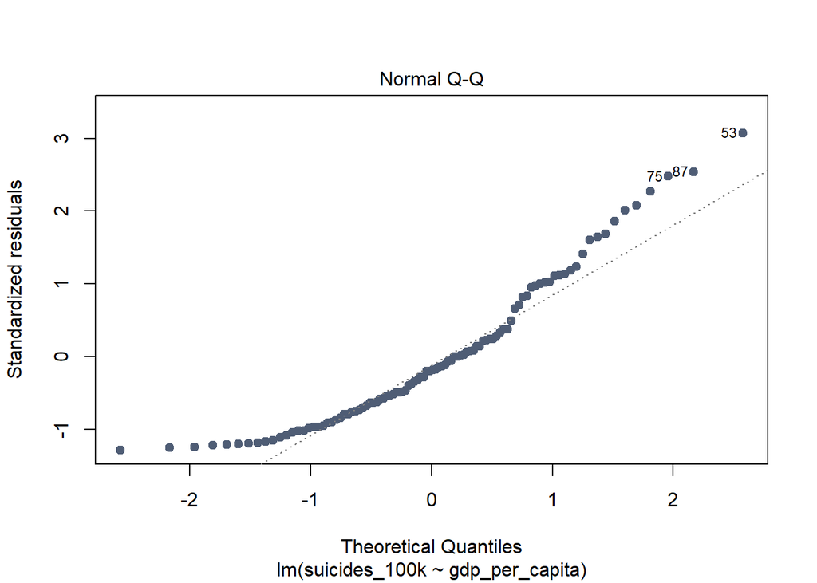

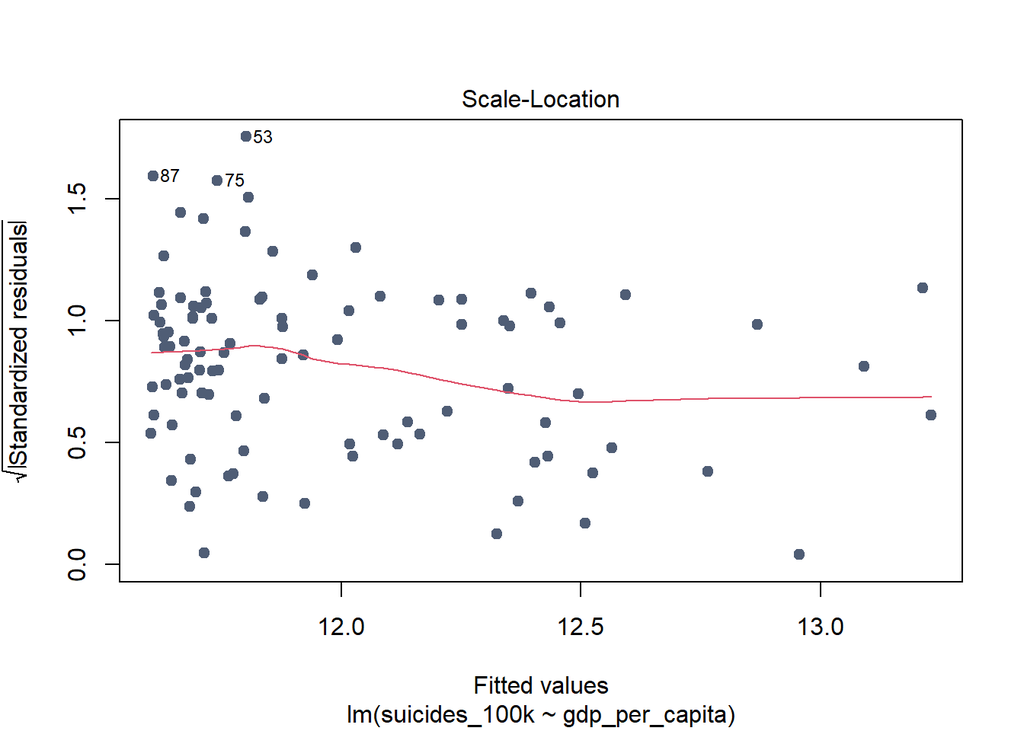

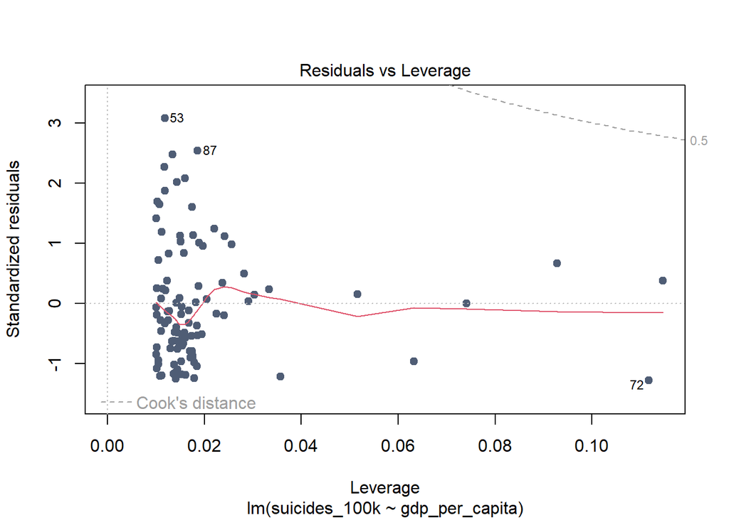

```r
plot(lm, col = "#4f5d75", pch = 19, legend.position = "top",
        plot.title = element_text(hjust = 0, size = 12, color = "#2d3142"),
        axis.title.x = element_text(margin = margin(t = 10), size = 8),
        axis.title.y = element_text(margin = margin(r = 10), size = 8),
        axis.text.x = element_text( vjust = 1, hjust = 1, size = 8),
        axis.text = element_text(size = 8))
```

#### **Podsumowanie**

Bazując na użytym zbiorze danych i odpowiadając na główne pytanie powyższej analizy, nie można potwierdzić, że poziom zamożności kraju wpływa na stopień samobójstw. Wyniki regresji liniowej oraz korelacji nie wskazują na takowy związek.

Analiza przyniosła za to odpowiedź na dodatkowe pytania.

**Według danych pokoleniem o najwyższym wskaźniku samobójstw jest pokolenie nazwane G.I Generation.**

1. G.I. Generation
2. Silent
3. Boomers
4. Generation X
5. Millenials
6. Generation Z

**Występuje istotna statystycznie dysproporcja we wskaźniku samobójstw pomiędzy kobietami a mężczyznami.**

Poniżej wynik testu-t.

```r
t.test(suicide_rates_overview$suicides_100k ~ suicide_rates_overview$sex)
```

```
##
##  Welch Two Sample t-test
##
## data:  suicide_rates_overview$suicides_100k by suicide_rates_overview$sex
## t = -70.633, df = 16509, p-value < 0.00000000000000022
## alternative hypothesis: true difference in means between group female and group male is not equal to 0
## 95 percent confidence interval:
##  -15.24444 -14.42120
## sample estimates:
## mean in group female   mean in group male
##             5.396188            20.229007
```

**Kraje o najwyższym wskaźniku samobójstw:**

1. Litwa
2. Sri Lanka
3. Rosja
4. Węgry
5. Białoruś
6. Kazachstan
7. Łotwa
8. Słowenia
9. Estonia
10. Ukraina

**Kraje o najniższym wskaźniku samobójstw:**

1. Bahrajn
2. Katar
3. Maledivy
4. Zjednoczone Emiraty Arabskie
5. Bahamy
6. Kuwejt
7. RPA
8. Oman
9. Antigua i Barbuda
10. Jamajka